# Biostat 203B Homework 4 Solution

Due Mar 19 @ 11:59PM

Liqiao (Vicky) Li

Load database libraries and the tidyverse frontend:

```r
library(tidyverse)
library(lubridate)
library(miceRanger)
library(data.table)
library(mice)
library(splitTools)
library(ranger)
library(purrr)
```

## Q1. Missing data

Through the Shiny app developed in HW3, we observe abundant missing values in the MIMIC-IV ICU cohort we created. In this question, we use multiple imputation to obtain a data set without missing values.

0. Read following tutorials on the R package miceRanger for imputation: https://github.com/farrellday/miceRanger, https://cran.r-project.org/web/packages/miceRanger/vignettes/miceAlgorithm.html.

```r
icu <- readRDS("icu_cohort.rds")

#modify variable "death_within_mon": NA indicates that the patient is not dead, so I replace NA with FALSE
icu <- icu %>%
  replace_na(list(death_within_mon = "FALSE"))

missing_values <- icu %>%
  as_tibble() %>%
  select(everything()) %>%
  summarise_all(funs(sum(is.na(.)))) %>%
  sort() %>%
  print(width = Inf)
```

```
## # A tibble: 1 x 46
##   subject_id hadm_id stay_id first_careunit last_careunit intime outtime   los
##        <int>   <int>   <int>          <int>         <int>  <int>   <int> <int>
## 1          0       0       0              0             0      0       0     0
##   admittime dischtime admission_type admission_location insurance language
##       <int>     <int>          <int>              <int>     <int>    <int>
## 1         0         0              0                  0         0        0
##   ethnicity hospital_expire_flag gender anchor_age anchor_year anchor_year_group
##       <int>                <int>  <int>      <int>       <int>             <int>
## 1         0                    0      0          0           0                 0
##   age_at_adm heart_rate death_within_mon respiratory_rate sodium chloride
##        <int>      <int>            <int>            <int>  <int>    <int>
## 1          0          0                0               24    161      170
##   creatinine glucose potassium bicarbonate hematocrit magnesium   wbc
##        <int>   <int>     <int>       <int>      <int>     <int> <int>
## 1        174     185       187         196        351       352   367
##   discharge_location non_invasive_blood_pressure_systolic
##                <int>                                <int>
## 1                376                                  550
##   non_invasive_blood_pressure_mean temperature_fahrenheit calcium marital_status
##                              <int>                  <int>   <int>          <int>
## 1                              571                    728    1709           4065
##   edregtime edouttime lactate arterial_blood_pressure_mean
##       <int>     <int>   <int>                        <int>
## 1     18385     18385   19175                        28284
##   arterial_blood_pressure_systolic deathtime   dod
##                              <int>     <int> <int>
## 1                            28403     44524 49377
```

Variables that have >5000 `NA`s include: edregtime, edouttime, lactate, arterial_blood_pressure_mean, arterial_blood_pressure_systolic, deathtime, and dod. However, NAs for dod and deathtime are meaningful, indicating that the patient is not dead so I will keep them for now and discard the others.

```r
#drop the unqualified variables
icu <- icu %>%
  as_tibble() %>%
  select(-c("edregtime","edouttime", "lactate",
            "arterial_blood_pressure_mean",
            "arterial_blood_pressure_systolic"))
```

Then I will replace the apparent data entry errors by `NA`s. I determine the outliers based on the plot observations in the Shiny app created in hw3. All observations that lie outside the common sense range are considered as potential outliers in the ICU cohort dataset.

```r
#clean the icu data#
icu <- icu %>%
  as_tibble() %>%
  #replace obvious outliers in vitals with NA
  mutate(heart_rate = replace(
    heart_rate, heart_rate< 30 |heart_rate> 250, NA)) %>%
  mutate(
    non_invasive_blood_pressure_systolic = replace(
      non_invasive_blood_pressure_systolic,
        non_invasive_blood_pressure_systolic > 500|non_invasive_blood_pressure_systolic < 20, NA)) %>%
  mutate(
    non_invasive_blood_pressure_mean =
           replace(non_invasive_blood_pressure_mean,
                   non_invasive_blood_pressure_mean > 500 |non_invasive_blood_pressure_mean < 20, NA)) %>%
  mutate(
    respiratory_rate = replace(
             respiratory_rate, respiratory_rate <2 | respiratory_rate > 150, NA)) %>%
  mutate(temperature_fahrenheit = replace(
      temperature_fahrenheit, temperature_fahrenheit <75, NA)) %>%
  #replace obvious outliers in lab measurements with NA
  mutate(calcium = replace(
    calcium, calcium >20|calcium == 0, NA)) %>%
  mutate(glucose = replace(
    glucose, glucose >2000, NA)) %>%
  mutate(magnesium = replace(
    magnesium,magnesium > 10, NA)) %>%
  mutate(wbc = replace(
    wbc, wbc ==0 | wbc > 400, NA)) %>%
  #drop some variables that will not be used in Q2
  select(-c("last_careunit", "intime", "los",
        "outtime","admittime", "dischtime",
        "deathtime", "admission_location", "hospital_expire_flag",
        "discharge_location", "insurance", "dod",
        "anchor_year", "anchor_year_group", "age_at_adm")) %>%
  #add a new variable age_squared
  mutate(age_squared = anchor_age^2) %>%
  print(width = Inf)
```

```
## # A tibble: 49,377 x 27
##    subject_id  hadm_id  stay_id first_careunit
##         <int>    <int>    <int> <chr>
##  1   10000032 29079034 37529680 Medical Intensive Care Unit (MICU)
##  2   10000980 26913865 36742749 Medical Intensive Care Unit (MICU)
##  3   10002013 23581541 37106138 Cardiac Vascular Intensive Care Unit (CVICU)
##  4   10002428 28662225 31956612 Medical Intensive Care Unit (MICU)
##  5   10002443 21329021 35217462 Coronary Care Unit (CCU)
##  6   10002760 28094813 36410867 Cardiac Vascular Intensive Care Unit (CVICU)
##  7   10003400 20214994 38355205 PACU
##  8   10004235 24181354 30276431 Coronary Care Unit (CCU)
##  9   10004422 21255400 39826382 Cardiac Vascular Intensive Care Unit (CVICU)
## 10   10004606 29242151 32639376 Neuro Surgical Intensive Care Unit (Neuro SICU)
##    admission_type              language marital_status ethnicity
##    <chr>                       <chr>    <chr>          <chr>
```

[output cut: 59 more lines]

4. Impute missing values by `miceRanger` (request $m=3$ datasets). This step is very computational intensive. Make sure to save the imputation results as a file.  
   **Solution**:

```r
#it takes 78 min to run the code below#
system.time(
 mice_icu <- miceRanger(
      icu,
      m=3,
      returnModels = TRUE,
      verbose=FALSE,
      max.depth = 10
  )
)
```

```r
#save the imputation results as a file#
saveRDS(mice_icu, "mice_icu.rds")
```

5. Make imputation diagnostic plots and explain what they mean.  
   **Solution**:

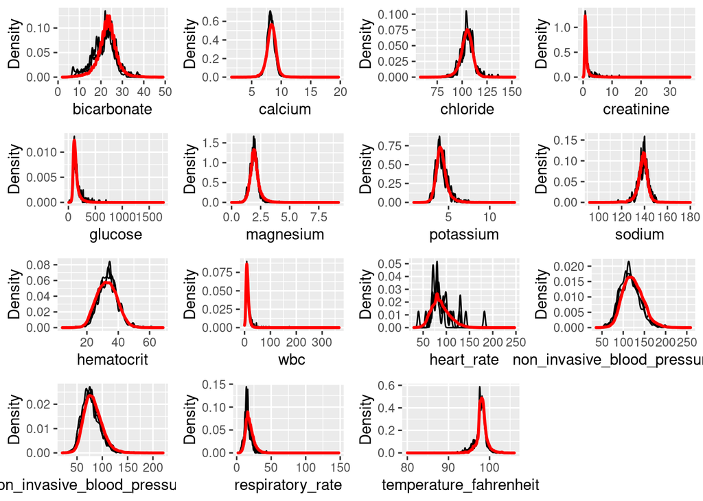

```r
#read the saved file created in Q1.4#
mice_icu <- readRDS("mice_icu.rds")
#Generate imputation diagnostic plots#
#Distribution of Imputed Values#
plotDistributions(mice_icu,vars= 'allNumeric')
```

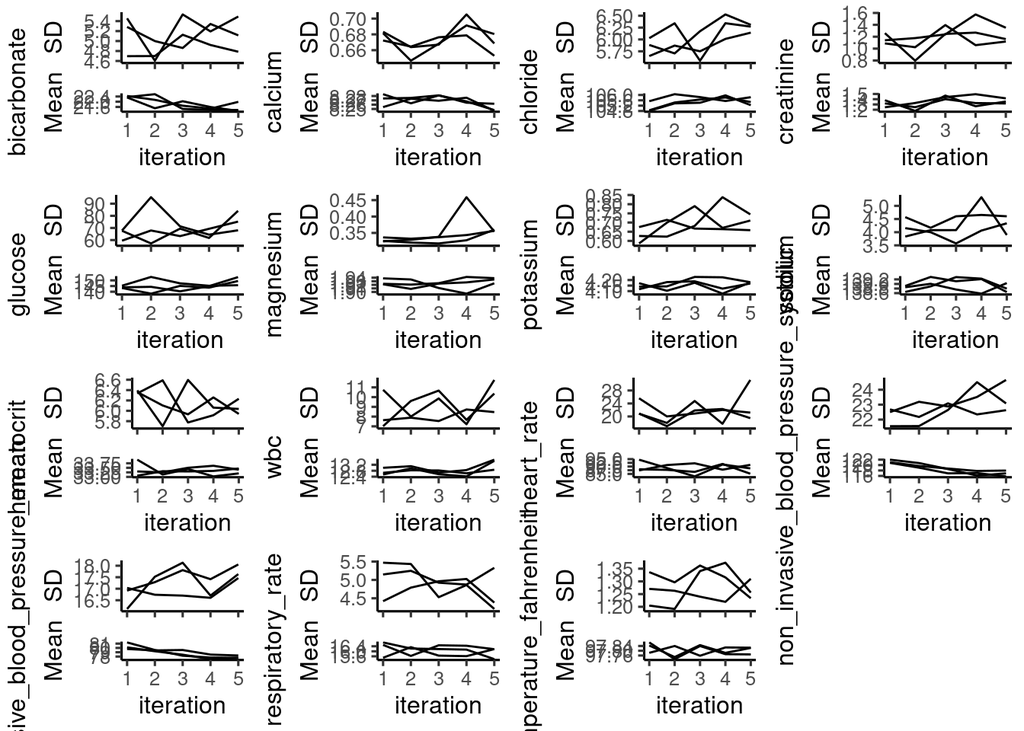

```r
#Center and Dispersion COnvergence#
plotVarConvergence(mice_icu,vars='allNumeric')
```

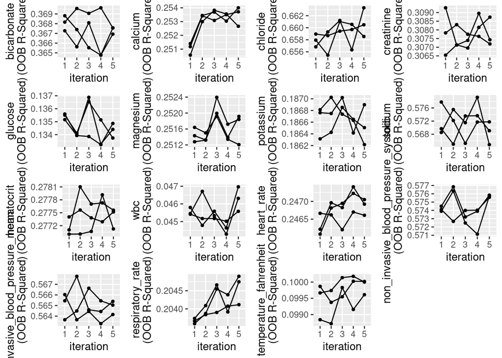

```r
#Model OOB Error#
plotModelError(mice_icu,vars='allNumeric')
```

The red line is the density of the original data and the black lines represent the imputed data in the first distribution plot. The red lines match well with the imputed lines for most variables except for heart_rate showing more noises. Each model shows the OOB accuracy for classification and r-squared for regression. Based on the OOB Error plots, we can see that most variables do not have a good accuracy. In sum, the imputed data are not converged yet. Ideally, we need to have more iterations. However, it has already been busy for the system to run with 5 iterations.

6. Obtain a complete data set by averaging the 3 imputed data sets.  
   **Solution**:

```r
dataList <- completeData(mice_icu)
#access each dataframe in the dataList
dataset1 <- dataList[[1]]
dataset2 <- dataList[[2]]
dataset3 <- dataList[[3]]

#convert categorical variables to numeric matrics using model.matrix
mod1 <- model.matrix(~ death_within_mon + anchor_age + age_squared +
            language + marital_status + ethnicity +
            gender + admission_type + first_careunit +
            bicarbonate + calcium + chloride + creatinine+
            glucose + magnesium + potassium + sodium +
            hematocrit + wbc + heart_rate +
            non_invasive_blood_pressure_systolic +
            non_invasive_blood_pressure_mean +
            respiratory_rate + temperature_fahrenheit,
                    data = dataset1)
mod2 <- model.matrix(~ death_within_mon + anchor_age + age_squared +
            language + marital_status + ethnicity +
            gender + admission_type + first_careunit +
            bicarbonate + calcium + chloride + creatinine+
            glucose + magnesium + potassium + sodium +
            hematocrit + wbc + heart_rate +
            non_invasive_blood_pressure_systolic +
            non_invasive_blood_pressure_mean +
            respiratory_rate + temperature_fahrenheit,
                    data = dataset2)
mod3 <- model.matrix(~ death_within_mon + anchor_age + age_squared +
            language + marital_status + ethnicity +
            gender + admission_type + first_careunit +
            bicarbonate + calcium + chloride + creatinine+
            glucose + magnesium + potassium + sodium +
            hematocrit + wbc + heart_rate +
            non_invasive_blood_pressure_systolic +
            non_invasive_blood_pressure_mean +
            respiratory_rate + temperature_fahrenheit,
                    data = dataset3)
```

```r
#combine the three datasets and take average
new_list <- list(mod1, mod2, mod3)
ave_icu <- reduce(new_list, `+`)/length(new_list)
```

## Q2. Predicting 30-day mortality

Develop at least two analytic approaches for predicting the 30-day mortality of patients admitted to ICU using demographic information (gender, age, marital status, ethnicity), first lab measurements during ICU stay, and first vital measurements during ICU stay. For example, you can use (1) logistic regression (`glm()` function), (2) logistic regression with lasso penalty (glmnet package), (3) random forest (randomForest package), or (4) neural network.

1. Partition data into 80% training set and 20% test set. Stratify partitioning according the 30-day mortality status.
2. Train the models using the training set.
3. Compare model prediction performance on the test set.

**Solution**:  
I will use logistic regression and neural network to perform the analysis.

###(1) Logistic regression First prepare the data for analysis. A logistic regression will be performed on the training set with gender, age, age_squared, marital status, ethnicity, language, first_careunit, admission_type, first lab measurements, and first vital measurements as the covariates. I will calculate the accuracy of the model to evaluate the predicted results.

```r
#convert the averaged matrix into data.frame
icu_final1 <- as.data.frame(ave_icu)

#partition data into 80% training set and 20% test set according to the 30-day mortality status
set.seed(12345)
inds <- partition(icu_final1$death_within_monTRUE, p =c(train = 0.8, test = 0.2))
str(inds)
```

```
## List of 2
##  $ train: int [1:39501] 1 2 3 4 5 6 7 8 9 10 ...
##  $ test : int [1:9876] 13 19 29 30 37 42 43 47 52 53 ...
```

```r
train <- icu_final1[inds$train, ]
test <- icu_final1[inds$test, ]

#build the logistic regression model
logit <- glm(death_within_monTRUE ~ . - (death_within_monTRUE),
            data = train, family = binomial)
summary(logit)
```

```
##
## Call:
## glm(formula = death_within_monTRUE ~ . - (death_within_monTRUE),
##     family = binomial, data = train)
##
## Deviance Residuals:
##     Min       1Q   Median       3Q      Max
## -3.1986  -0.4458  -0.2943  -0.1678   3.4449
##
## Coefficients: (1 not defined because of singularities)
##                                                                    Estimate
## (Intercept)                                                      -3.365e+00
## `(Intercept)`                                                            NA
## anchor_age                                                        4.626e-02
## age_squared                                                      -1.152e-04
## languageENGLISH                                                   7.113e-02
## marital_statusMARRIED                                            -6.889e-02
## marital_statusSINGLE                                             -4.002e-02
## marital_statusWIDOWED                                             3.017e-02
## ethnicityASIAN                                                    2.766e-01
## `ethnicityBLACK/AFRICAN AMERICAN`                                 3.950e-02
## `ethnicityHISPANIC/LATINO`                                        1.635e-01
## ethnicityOTHER                                                    3.526e-01
## `ethnicityUNABLE TO OBTAIN`                                       1.075e+00
## ethnicityUNKNOWN                                                  1.014e+00
## ethnicityWHITE                                                    1.410e-01
## genderM                                                           5.027e-02
## `admission_typeDIRECT EMER.`                                      1.139e+01
## `admission_typeDIRECT OBSERVATION`                                1.166e+01
## admission_typeELECTIVE                                            1.047e+01
## `admission_typeEU OBSERVATION`                                    1.125e+01
## `admission_typeEW EMER.`                                          1.170e+01
## `admission_typeOBSERVATION ADMIT`                                 1.134e+01
## `admission_typeSURGICAL SAME DAY ADMISSION`                       9.980e+00
## admission_typeURGENT                                              1.167e+01
## `first_careunitCoronary Care Unit (CCU)`                          8.685e-01
## `first_careunitMedical Intensive Care Unit (MICU)`                1.144e+00
## `first_careunitMedical/Surgical Intensive Care Unit (MICU/SICU)`  1.059e+00
## first_careunitMedicine                                            2.973e+00
## `first_careunitNeuro Intermediate`                               -2.152e-01
```

[output cut: 165 more lines]

```
## heart_rate                                                        < 2e-16 ***
## non_invasive_blood_pressure_systolic                              < 2e-16 ***
## non_invasive_blood_pressure_mean                                  0.69753
## respiratory_rate                                                  < 2e-16 ***
## temperature_fahrenheit                                            < 2e-16 ***
## ---
## Signif. codes:  0 '***' 0.001 '**' 0.01 '*' 0.05 '.' 0.1 ' ' 1
##
## (Dispersion parameter for binomial family taken to be 1)
##
##     Null deviance: 24351  on 39500  degrees of freedom
## Residual deviance: 19818  on 39453  degrees of freedom
## AIC: 19914
##
## Number of Fisher Scoring iterations: 13
```

```r
#predict the 30-day mortality of ICU patients
pred <- predict(logit, test, type = "response")
#create a dataframe of observed and predicted data
library(yardstick)
predicted <- round(pred)
tab <- table(Predicted = predicted, Reference = test$death_within_monTRUE)
tab
```

```
##          Reference
## Predicted    0    1
##         0 8904  831
##         1   59   82
```

```r
#calculate the accuracy
act_pred <- data.frame(observed = factor(test$death_within_monTRUE), predicted =
                      factor(predicted))
accuracy_est <- accuracy(act_pred, observed, predicted) %>%
  print()
```

```
## # A tibble: 1 x 3
##   .metric  .estimator .estimate
##   <chr>    <chr>          <dbl>
## 1 accuracy binary         0.910
```

The coefficient table shows that age, ethnicity`Unable to obtain` and unknown, first careunits including CCU, MICU, MICU/SICU, Medicine, Neuro SICU, SICU, and TSICU, all lab measurements, and vital measurements including heart_rate, non_invasive_blood_pressure_systolic, respiratory_rate, and temperature, have significant influence on the 30-day mortality (p-value < 0.05). The accuracy of the logistic regression model is estimated as 0.9099.

###(2) Neural network Define a sequential model (a linear stack of layers) with 2 fully-connected hidden layers (50 and 25 neurons).

```r
library(keras)
install_keras()
```

```
##
## Installation complete.
```

```r
library(tensorflow)
#prepare data and use the partitioned data
x_train <- as.matrix(train[,3:49])
y_train <- as.matrix(train[,2])

dim(x_train)
```

```
## [1] 39501    47
```

```r
dim(y_train)
```

```
## [1] 39501     1
```

```r
x_test <- as.matrix(test[,3:49])
y_test <- as.matrix(test[,2])
dim(x_test)
```

```
## [1] 9876   47
```

```r
dim(y_test)
```

```
## [1] 9876    1
```

```r
#define the model
model <- keras_model_sequential()
```

```r
model %>%
  layer_dense(units = 50, activation = 'relu', input_shape = c(47)) %>%
  layer_dropout(rate= 0.4) %>%
  layer_dense(units = 25, activation = 'relu') %>%
  layer_dropout(rate = 0.3) %>%
  layer_dense(units = 2, activation = 'softmax')
summary(model)
```

```
## Model: "sequential"
## ________________________________________________________________________________
## Layer (type)                        Output Shape                    Param #
## ================================================================================
## dense_2 (Dense)                     (None, 50)                      2400
## ________________________________________________________________________________
## dropout_1 (Dropout)                 (None, 50)                      0
## ________________________________________________________________________________
## dense_1 (Dense)                     (None, 25)                      1275
## ________________________________________________________________________________
## dropout (Dropout)                   (None, 25)                      0
## ________________________________________________________________________________
## dense (Dense)                       (None, 2)                       52
## ================================================================================
## Total params: 3,727
## Trainable params: 3,727
## Non-trainable params: 0
## ________________________________________________________________________________
```

```r
#compile the model with loss function, optimizer, and metrics
model %>% compile(
  loss = 'sparse_categorical_crossentropy',
  optimizer = optimizer_rmsprop(),
  metrics = c('accuracy')
)
```

```r
#train the model
#it takes about 28 seconds
system.time({
history <- model %>% fit(
  x_train, y_train,
  epochs = 10, batch_size = 25,
  validation_split = 0.2
)
})
```

```
##    user  system elapsed
##  35.020   3.707  24.889
```

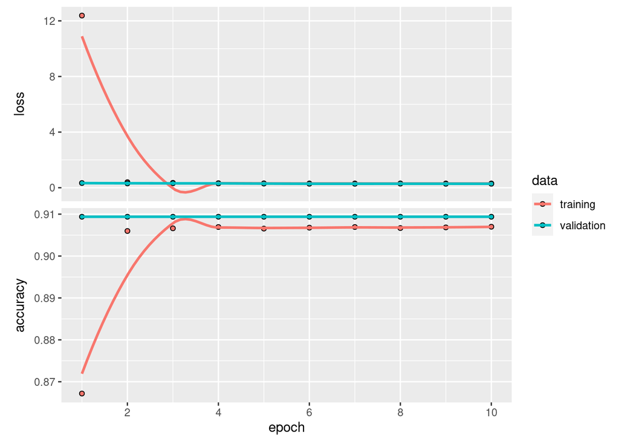

```r
plot(history)
```

```r
#evaluate model performance and test data
model %>% evaluate(x_test, y_test)
```

```
##      loss  accuracy
## 0.2897950 0.9075537
```

I have tried different parameters of the model and achieved the loss of 0.29 and accuracy of 0.9076.

Overall, both logistic regression and neural network models result in a good prediction accuracy that is about 0.91. The accuracy of the logistic regression model and neural network model is about the same.